# ProjetR: Bank Marketing Data

Rida Boushab

16/01/2021

[figure not shown]

## Data Source

●Le jeu de données url: https://www.kaggle.com/janiobachmann/bank-marketing-dataset  
●17 attributs, 11162 lignes de données(rows)  
●Le but de ce jeu de données est de predire si un client va souscrire à un dépôt à terme( deposit).

```r
#reading the data
bank <- read.csv("../bank.csv", header=T)
#eliminate all null rows
all.empty = rowSums(is.na(bank))==ncol(bank)
bankData = bank[!all.empty,]
head(bankData)
```

|  | age | job | marital | education | default | balance | housing | loan | contact | day | month | duration | campaign | pdays | previous | poutcome | deposit |
| --- | --- | --- | --- | --- | --- | --- | --- | --- | --- | --- | --- | --- | --- | --- | --- | --- | --- |
| 1 | 59 | admin. | married | secondary | no | 2343 | yes | no | unknown | 5 | may | 1042 | 1 | -1 | 0 | unknown | yes |
| 2 | 56 | admin. | married | secondary | no | 45 | no | no | unknown | 5 | may | 1467 | 1 | -1 | 0 | unknown | yes |
| 3 | 41 | technician | married | secondary | no | 1270 | yes | no | unknown | 5 | may | 1389 | 1 | -1 | 0 | unknown | yes |
| 4 | 55 | services | married | secondary | no | 2476 | yes | no | unknown | 5 | may | 579 | 1 | -1 | 0 | unknown | yes |
| 5 | 54 | admin. | married | tertiary | no | 184 | no | no | unknown | 5 | may | 673 | 2 | -1 | 0 | unknown | yes |
| 6 | 42 | management | single | tertiary | no | 0 | yes | yes | unknown | 5 | may | 562 | 2 | -1 | 0 | unknown | yes |

## Différentes caractéristiques de la data set

```r
#give information about the data like (min, max, avg etc.)
summary(bankData)
```

```
##       age            job              marital           education
##  Min.   :18.00   Length:11162       Length:11162       Length:11162
##  1st Qu.:32.00   Class :character   Class :character   Class :character
##  Median :39.00   Mode  :character   Mode  :character   Mode  :character
##  Mean   :41.23
##  3rd Qu.:49.00
##  Max.   :95.00
##    default             balance        housing              loan
##  Length:11162       Min.   :-6847   Length:11162       Length:11162
##  Class :character   1st Qu.:  122   Class :character   Class :character
##  Mode  :character   Median :  550   Mode  :character   Mode  :character
##                     Mean   : 1529
##                     3rd Qu.: 1708
##                     Max.   :81204
##    contact               day           month              duration
##  Length:11162       Min.   : 1.00   Length:11162       Min.   :   2
##  Class :character   1st Qu.: 8.00   Class :character   1st Qu.: 138
##  Mode  :character   Median :15.00   Mode  :character   Median : 255
##                     Mean   :15.66                      Mean   : 372
##                     3rd Qu.:22.00                      3rd Qu.: 496
##                     Max.   :31.00                      Max.   :3881
##     campaign          pdays           previous         poutcome
##  Min.   : 1.000   Min.   : -1.00   Min.   : 0.0000   Length:11162
##  1st Qu.: 1.000   1st Qu.: -1.00   1st Qu.: 0.0000   Class :character
##  Median : 2.000   Median : -1.00   Median : 0.0000   Mode  :character
##  Mean   : 2.508   Mean   : 51.33   Mean   : 0.8326
##  3rd Qu.: 3.000   3rd Qu.: 20.75   3rd Qu.: 1.0000
##  Max.   :63.000   Max.   :854.00   Max.   :58.0000
##    deposit
##  Length:11162
##  Class :character
##  Mode  :character
##
##
##
```

## La structuration de la data set

```r
str(bankData)
```

```
## 'data.frame':    11162 obs. of  17 variables:
##  $ age      : int  59 56 41 55 54 42 56 60 37 28 ...
##  $ job      : chr  "admin." "admin." "technician" "services" ...
##  $ marital  : chr  "married" "married" "married" "married" ...
##  $ education: chr  "secondary" "secondary" "secondary" "secondary" ...
##  $ default  : chr  "no" "no" "no" "no" ...
##  $ balance  : int  2343 45 1270 2476 184 0 830 545 1 5090 ...
##  $ housing  : chr  "yes" "no" "yes" "yes" ...
##  $ loan     : chr  "no" "no" "no" "no" ...
##  $ contact  : chr  "unknown" "unknown" "unknown" "unknown" ...
##  $ day      : int  5 5 5 5 5 5 6 6 6 6 ...
##  $ month    : chr  "may" "may" "may" "may" ...
##  $ duration : int  1042 1467 1389 579 673 562 1201 1030 608 1297 ...
##  $ campaign : int  1 1 1 1 2 2 1 1 1 3 ...
##  $ pdays    : int  -1 -1 -1 -1 -1 -1 -1 -1 -1 -1 ...
##  $ previous : int  0 0 0 0 0 0 0 0 0 0 ...
##  $ poutcome : chr  "unknown" "unknown" "unknown" "unknown" ...
##  $ deposit  : chr  "yes" "yes" "yes" "yes" ...
```

## La correlation

La correlation entre les variables du data set afin de voir les variables dominants

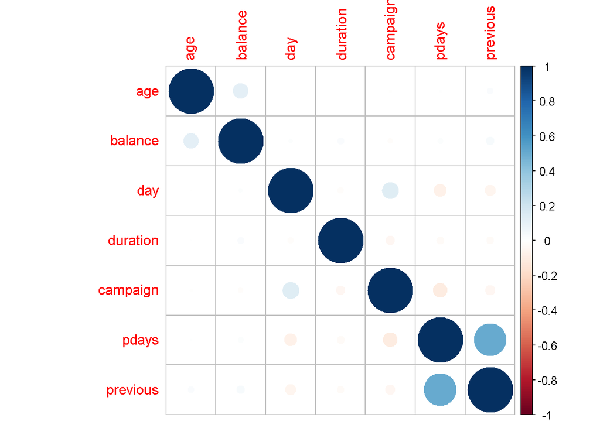

```r
library(corrplot)
corrdata<-data.frame(bankData[, lapply(bankData, is.numeric) == TRUE])
cory<-cor(corrdata)
corrplot(cory)
```

## Analyse d’âge

Le jeu de données est composé des personnes principalement entre 32 et 49 ans  
L’âge maximum est de 95 ans et le minimum est de 18 ans

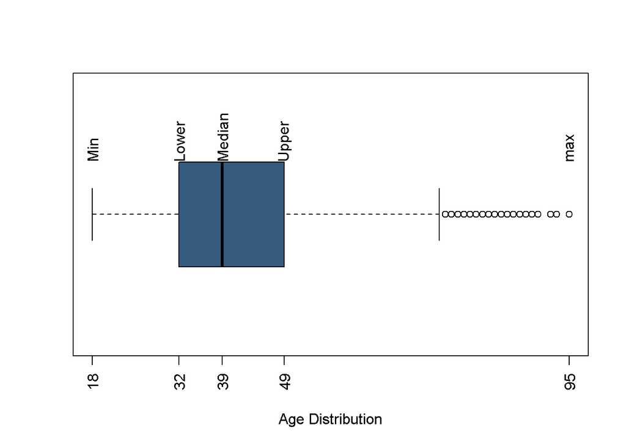

```r
boxplot(bankData$age, col="#375A7F",xaxt="n",
              xlab="Age Distribution", horizontal=TRUE)
axis(side=1, at=fivenum(bankData$age), labels=TRUE,las=2)
text(fivenum(bankData$age),rep(1.2,5),srt=90,adj=0,
labels=c("Min","Lower","Median","Upper","max"))
```

## Analyse du balance et job

Ce nuage de points montre la distribution du balance pour chaque job

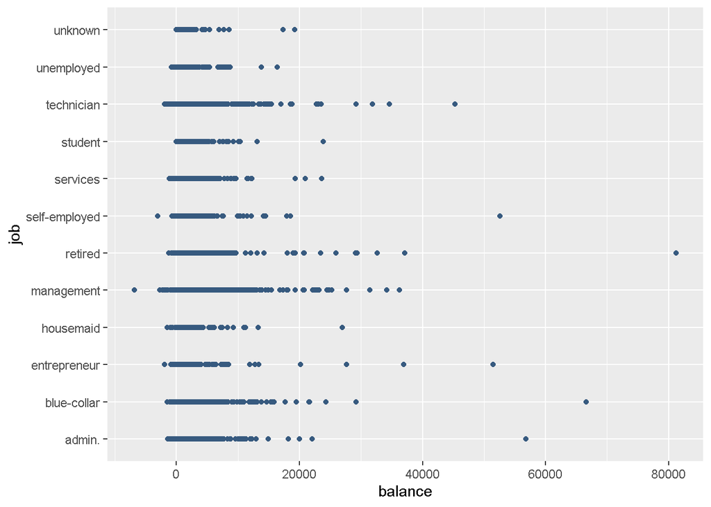

```r
library(ggplot2)
ggplot(bankData ,aes(x=balance ,y= job))+geom_point( color ="#375A7F")
```

## Analyse du marital

On remarque que les clients mariée qui domine le jeu de données

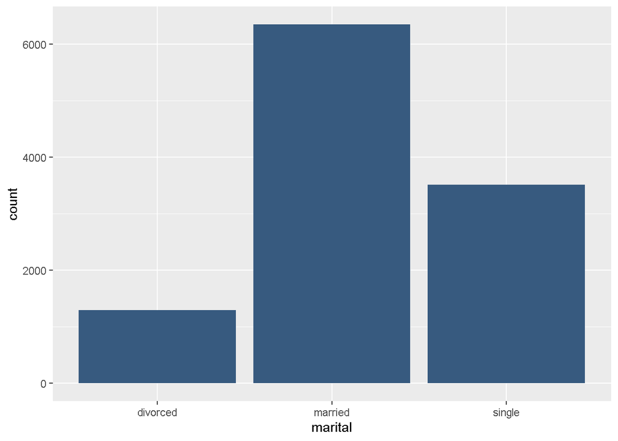

```r
ggplot (bankData ,aes (x=marital)) + geom_bar(fill="#375A7F")
```

## Analyse de type d’education

On remarque que les clients de niveau “Secondary” qui domine

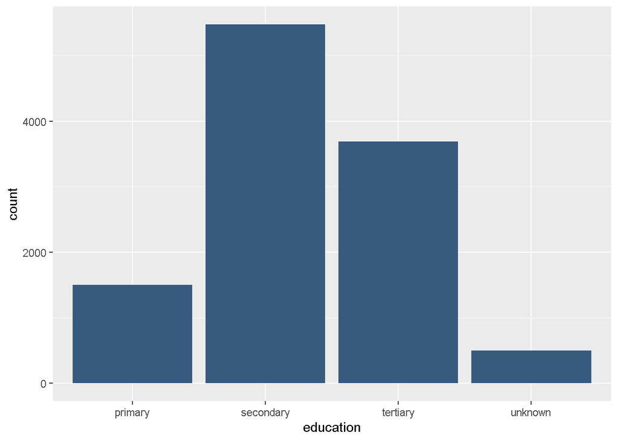

```r
ggplot (bankData ,aes (x=education)) + geom_bar(fill="#375A7F")
```

## Analyse depot et l’age

```r
library(tidyverse)
```

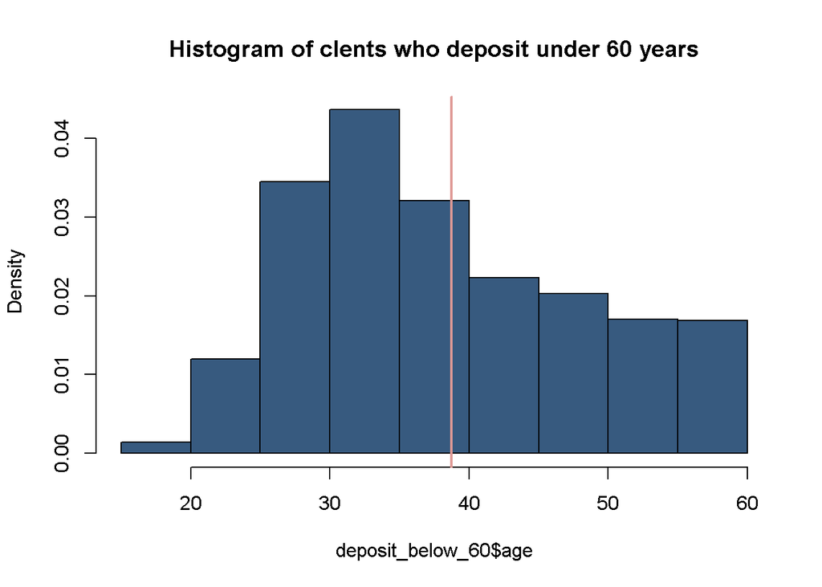

```r
deposit_filter <- filter(bankData, bankData$deposit == "yes")
deposit_below_60<- filter(deposit_filter, deposit_filter$age <= 60)
mean<-mean(deposit_below_60$age)
sd<-sd(deposit_below_60$age)
hist(deposit_below_60$age, prob=TRUE, col="#375A7F",main="Histogram of clents who deposit under 60 years")
abline(v = mean, col = "#df9995", lwd = 2)
```

## Test

Le solde(balance) a-t-il un effet sur le dépôt(deposit) à terme?  
H0: le solde n’a aucun effet sur le dépôt à terme  
H1: le solde a un effet sur le dépôt à terme

```r
with(data=bankData,t.test(balance[deposit=="no"],balance[deposit=="yes"],var.equal=TRUE))
```

```
##
##  Two Sample t-test
##
## data:  balance[deposit == "no"] and balance[deposit == "yes"]
## t = -8.5988, df = 11160, p-value < 2.2e-16
## alternative hypothesis: true difference in means is not equal to 0
## 95 percent confidence interval:
##  -643.5002 -404.5814
## sample estimates:
## mean of x mean of y
##  1280.227  1804.268
```

La p-valeur est largement inférieure à 5%. Donc, on rejette l’hypothèse nulle.

## Prédiction

Le modèle de prediction utilisé c’est une arbre de decision, on veut predire si un client va souscrire ou non à un dépôt à terme( deposit), en prenant 16 variables du jeu de donnees(sauf la variable deposit, c’est elle quand veut predire), pour les variables de type qualitatif on va les encoder afin de les utiliser dans l’arbre de decision.

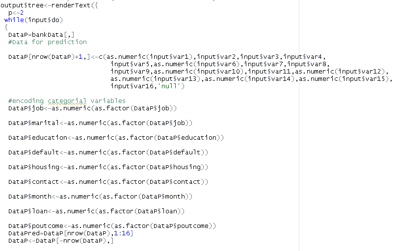

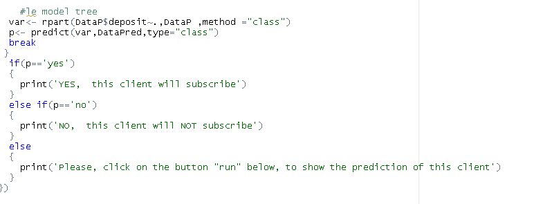

la librarie “library(rpart.plot)” permet de genérer la règle de decision pour les variables intréssant.

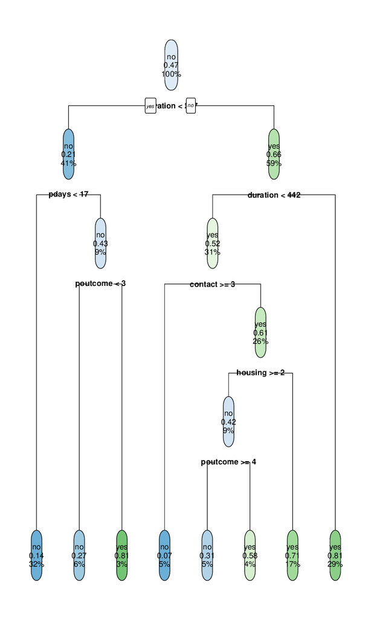

## Conclusion

Les personnes dont l’âge entre 30 et 40 ans doivent être ciblées pour la campagne de marketing parceque ce groupe d’âge déposent le plus.